# assignment 3~325

Adan Martinez-Ponce

2026-04-10

## Project Description:

Data pulled from: https://www.football-data.co.uk/englandm.php

Going to look at 20 years of premier leauge soccer statistics and going to examine if the home field advantage is still relevant in the Premier Leauge.

I had to download all the csv files per season separate, and I created a python script with the gelp of Gemini Pro-3 to write a python script to go and make a huge master excel sheet, otherwise to copy and past it all would have taken a long time.

Now my data is ready to plug into R here and get started with the Arima model! I also used Gemini Pro-3 to clean some debugging errrors I had.

```r
# Load libraries
library(tidyverse)
library(fable)
library(tsibble)
library(feasts)
library(lubridate)

# 1. Load data
prem_data <- read_csv("C:/Users/armp1/Downloads/assignment3data/allpremdata.csv")

# 2. Convert to Time Series
monthly_prem <- prem_data |>
  # CORRECTED: Changed 'ymd' to 'mdy' to match your data's Month-Day-Year format
  mutate(Date = mdy(Date)) |>
  # DROP THE JUNK: remove any rows where the date didn't parse correctly
  drop_na(Date) |>
  # Create time series index
  mutate(Month = yearmonth(Date)) |>
  # find metric: Home Goals minus Away Goals
  mutate(Home_Advantage = FTHG - FTAG) |>
  # Group everything by month
  group_by(Month) |>
  summarise(Avg_Home_Advantage = mean(Home_Advantage, na.rm = TRUE)) |>
  # Convert to a tsibble
  as_tsibble(index = Month) |>
  # Prem doesn't play from june-august, so need to fill in gaps
  fill_gaps() |>
  # If no games were played in July, the home advantage was exactly 0
  mutate(Avg_Home_Advantage = replace_na(Avg_Home_Advantage, 0))
glimpse(monthly_prem)
```

```
## Rows: 260
## Columns: 2
## $ Month              <mth> 2004 Aug, 2004 Sep, 2004 Oct, 2004 Nov, 2004 Dec, 2…
## $ Avg_Home_Advantage <dbl> 0.46153846, 0.30000000, 0.48717949, -0.14634146, 0.…
```

```r
# 3. Create the 80/20 Train/Test Split
# 22 years of data * 12 months = ~264 rows. 80% of 264 is roughly 211 months, going to  train the model on everything before 2021, and test it on 2021-Present.
train_data <- monthly_prem |>
  filter(year(Month) < 2021)

test_data <- monthly_prem |>
  filter(year(Month) >= 2021)
```

Next I”m going to make a visual to plot the raw data.

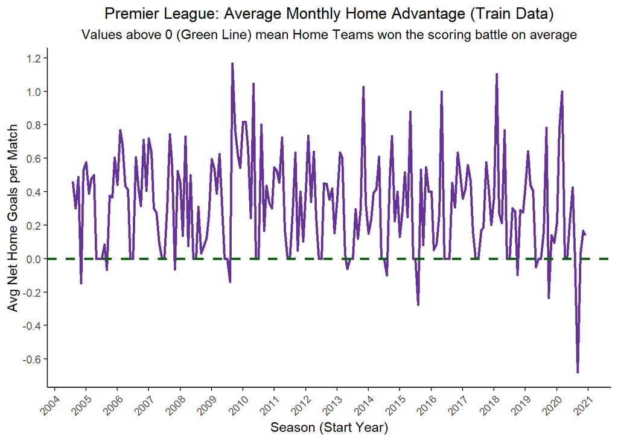

```r
# Plotting the raw training
train_data |>
  ggplot(aes(x = Month, y = Avg_Home_Advantage)) +
  # usuing prem purple
  geom_line(color = "#663399", linewidth = 1) +
  # Adding 'grass' baseline
  geom_hline(yintercept = 0, linetype = "dashed", color = "darkgreen", linewidth = 1) +
  # Improving the X-axis: Breaking it down by 1 year and formatting as "YYYY"
  scale_x_yearmonth(date_breaks = "1 year", date_labels = "%Y") +
  # Giving the Y-axis fixed limits and forcing clean 1-decimal numbers
  scale_y_continuous(breaks = seq(-0.6, 1.2, 0.2), labels = function(x) sprintf("%.1f", x)) +
  labs(title = "Premier League: Average Monthly Home Advantage (Train Data)",
       subtitle = "Values above 0 (Green Line) mean Home Teams won the scoring battle on average",
       x = "Season (Start Year)",
       y = "Avg Net Home Goals per Match") +
  theme_classic() +
  theme(plot.title = element_text(hjust = 0.5),
        plot.subtitle = element_text(hjust = 0.5),
        axis.text.x = element_text(angle = 45, hjust = 1))
```

It took a bit to plot the data because R was being odd with the formating with scientific notation, so I had to figure out how to round correctly. Other then that tho I’m very happy with how the graph turned out! I really like the purple accent because it matches prem leauge theme color.

Also in the data, you can see spikes and seasons where the away team was better, and during the 2020 season, you can see the away team is the best ever becuase there was no home team advantage that year as there were no fans in the stadium, so every game was a neautral venue basically.

Now going to plot a ACF plot:

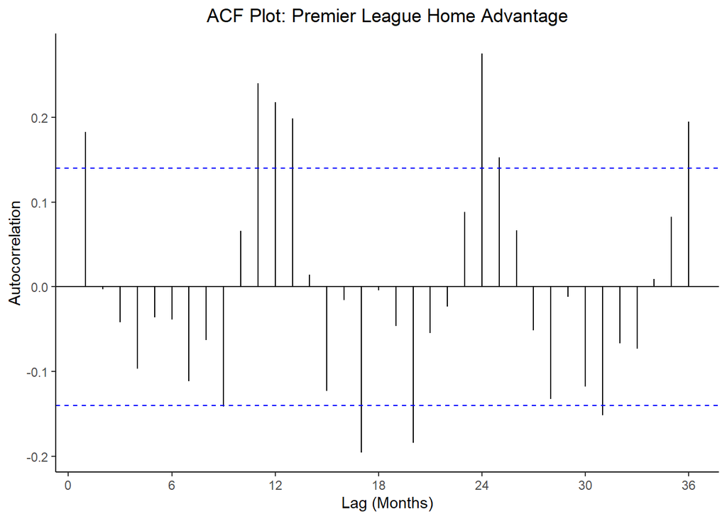

```r
# Plotting ACF of our training data
train_data |>
  ACF(Avg_Home_Advantage, lag_max = 36) |>
  autoplot() +
  labs(title = "ACF Plot: Premier League Home Advantage",
       x = "Lag (Months)",
       y = "Autocorrelation") +
  theme_classic() +
  theme(plot.title = element_text(hjust = 0.5))
```

Part: ACF Plot Discussion

The ACF plot of the training data reveals strong, statistically significant seasonality in the Premier League’s home advantage. There are distinct, positive autocorrelation spikes at lags 12, 24, and 36 that extend well beyond blue dashed lines. This confirms a 12-month annual cycle, reflecting the natural structure of the English soccer calendar.

Part 3: stationary test and model building:

```r
# Stationarity Test
# Run the KPSS test to see if the data is stationary
train_data |> features(Avg_Home_Advantage, unitroot_kpss)
```

```
## # A tibble: 1 × 2
##   kpss_stat kpss_pvalue
##       <dbl>       <dbl>
## 1     0.337         0.1
```

```r
# check on differences
train_data |> features(Avg_Home_Advantage, unitroot_ndiffs)
```

```
## # A tibble: 1 × 1
##   ndiffs
##    <int>
## 1      0
```

```r
# building arima model
fit_arima <- train_data |>
  model(arima = ARIMA(Avg_Home_Advantage))

# model equation
report(fit_arima)
```

```
## Series: Avg_Home_Advantage
## Model: ARIMA(0,0,0)(2,0,0)[12] w/ mean
##
## Coefficients:
##         sar1    sar2  constant
##       0.1733  0.2865    0.1674
## s.e.  0.0706  0.0740    0.0181
##
## sigma^2 estimated as 0.07647:  log likelihood=-26.18
## AIC=60.36   AICc=60.57   BIC=73.49
```

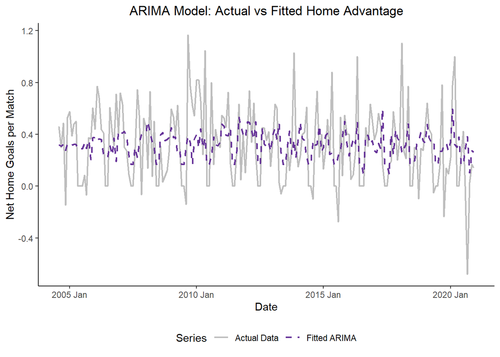

```r
# plotting actual vs fitted:
augment(fit_arima) |>
  ggplot(aes(x = Month)) +
  geom_line(aes(y = Avg_Home_Advantage, color = "Actual Data"), linewidth = 0.8) +
  geom_line(aes(y = .fitted, color = "Fitted ARIMA"), linetype = "dashed", linewidth = 0.8) +
  scale_color_manual(values = c("Actual Data" = "gray", "Fitted ARIMA" = "#663399")) +
  labs(title = "ARIMA Model: Actual vs Fitted Home Advantage",
       x = "Date",
       y = "Net Home Goals per Match",
       color = "Series") +
  theme_classic() +
  theme(plot.title = element_text(hjust = 0.5), legend.position = "bottom")
```

Stationarity and ARIMA Fit To check the data, I ran a KPSS test which returned a p-value of 0.1, alongside an ndiffs result of 0. Because the p-value is greater than 0.05, this says that the raw training data is already stationary and does not require any differencing.

The fable package automatically selected an ARIMA(0,0,0)(2,0,0)[12] model with a non-zero mean. This model relies entirely on the seasonal components rather than short-term autoregression. It essentially uses the data from the exact same month over the previous two years to predict the current month’s home advantage.

Residuals & RMSE:

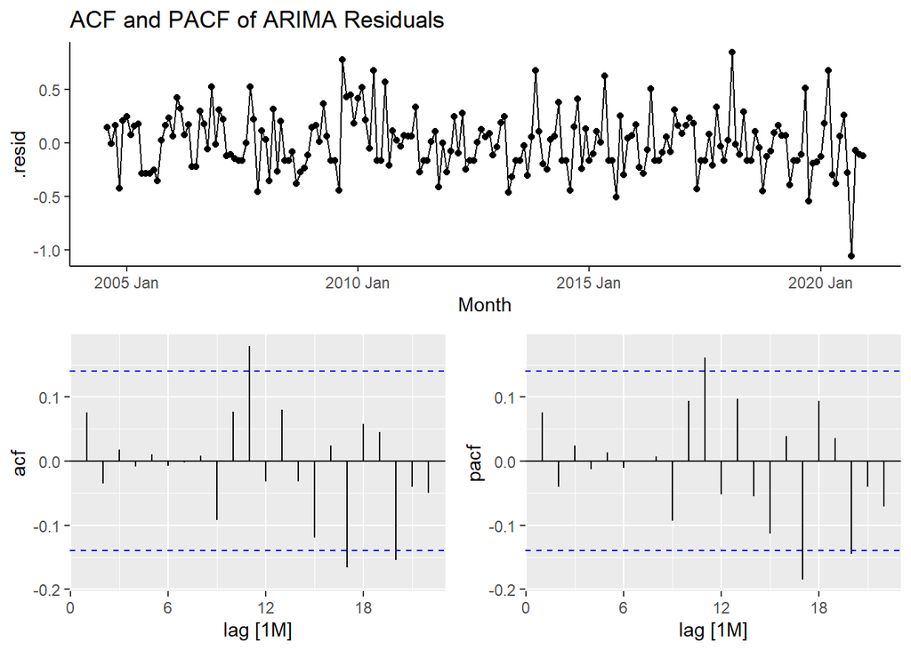

```r
# Plot ACF resid
augment(fit_arima) |>
  gg_tsdisplay(.resid, plot_type = "partial") +
  labs(title = "ACF and PACF of ARIMA Residuals") +
  theme_classic()
```

```r
# find rmse
accuracy(fit_arima) |>
  select(.model, .type, RMSE, MAE, MAPE) |>
  knitr::kable()
```

| .model | .type | RMSE | MAE | MAPE |
| --- | --- | --- | --- | --- |
| arima | Training | 0.2744163 | 0.2156655 | Inf |

Moving on to exponential smoothing:

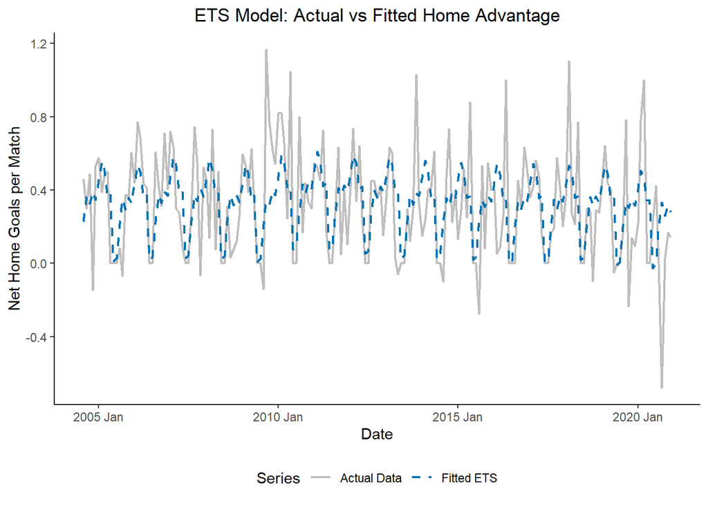

```r
#Fit Exponential Smoothing (ETS)
fit_ets <- train_data |>
  model(ets = ETS(Avg_Home_Advantage))

# actual vs fitted ETS
augment(fit_ets) |>
  ggplot(aes(x = Month)) +
  geom_line(aes(y = Avg_Home_Advantage, color = "Actual Data"), linewidth = 0.8) +
  geom_line(aes(y = .fitted, color = "Fitted ETS"), linetype = "dashed", linewidth = 0.8) +
  scale_color_manual(values = c("Actual Data" = "gray", "Fitted ETS" = "#0072B2")) + # Using blue for the second model
  labs(title = "ETS Model: Actual vs Fitted Home Advantage",
       x = "Date",
       y = "Net Home Goals per Match",
       color = "Series") +
  theme_classic() +
  theme(plot.title = element_text(hjust = 0.5), legend.position = "bottom")
```

```r
# finding rmse
accuracy(fit_ets) |>
  select(.model, .type, RMSE, MAE, MAPE) |>
  knitr::kable()
```

| .model | .type | RMSE | MAE | MAPE |
| --- | --- | --- | --- | --- |
| ets | Training | 0.2511049 | 0.183706 | Inf |

ETS:

For our comparison model, I ran a Holt-Winters (ETS) model, which is made to handle strong seasonal data. Looking at the plot, the blue dashed line traces the rolling 12-month wave of the Premier League season. It actually outperformed the ARIMA model on the training data, scoring a lower RMSE of 0.25 (compared to ARIMA’s 0.27). The ETS model proves to be a highly accurate fit for the historical data.

You can also see the waves of seasonality in the ETS model, and looks a lot more fluid compared to ARIMA.

Final part: plotting ETS resid, then forecast the 2021+ and test on unseen data, and find rmse to see which model is better.

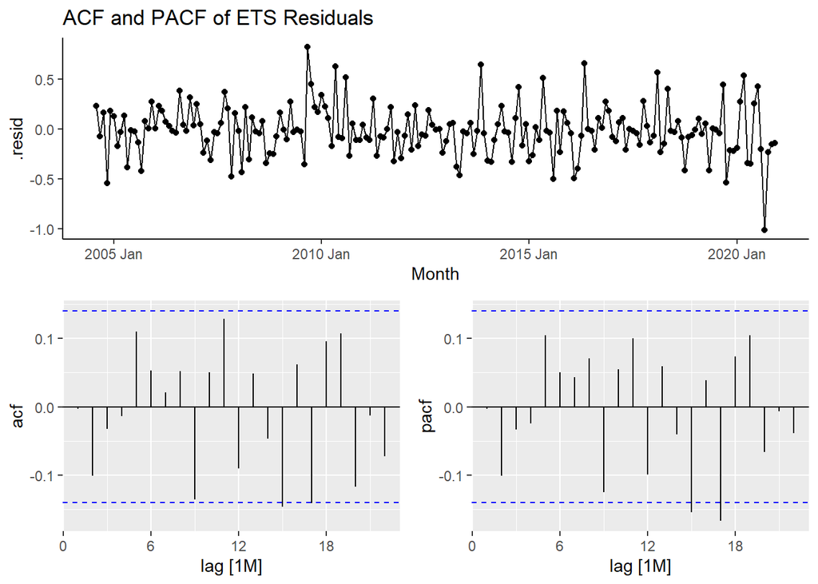

```r
# ets resid
augment(fit_ets) |>
  gg_tsdisplay(.resid, plot_type = "partial") +
  labs(title = "ACF and PACF of ETS Residuals") +
  theme_classic()
```

```r
# forecast arima & ets
forecast_arima <- fit_arima |> forecast(new_data = test_data)
forecast_ets <- fit_ets |> forecast(new_data = test_data)

# test both models
bind_rows(
  accuracy(forecast_arima, monthly_prem),
  accuracy(forecast_ets, monthly_prem)
) |>
  select(.model, .type, RMSE, MAE) |>
  knitr::kable()
```

| .model | .type | RMSE | MAE |
| --- | --- | --- | --- |
| arima | Test | 0.3253514 | 0.2736324 |
| ets | Test | 0.3212010 | 0.2476701 |

SUmmary, comparison & results:

To determine the best method, both the ARIMA and ETS models predicted on unseen data (test:2021–Present). The results were very close, but the Exponential Smoothing (ETS) model was a touch better.

ETS had a Test RMSE of 0.321 compared to the ARIMA’s 0.325. Because the Premier League’s home advantage relies heavily on a rigid, recurring 12-month calendar, the ETS model’s ability to track and project strong seasonal waves gave it a better score I think. Overall, both models were very accurate.

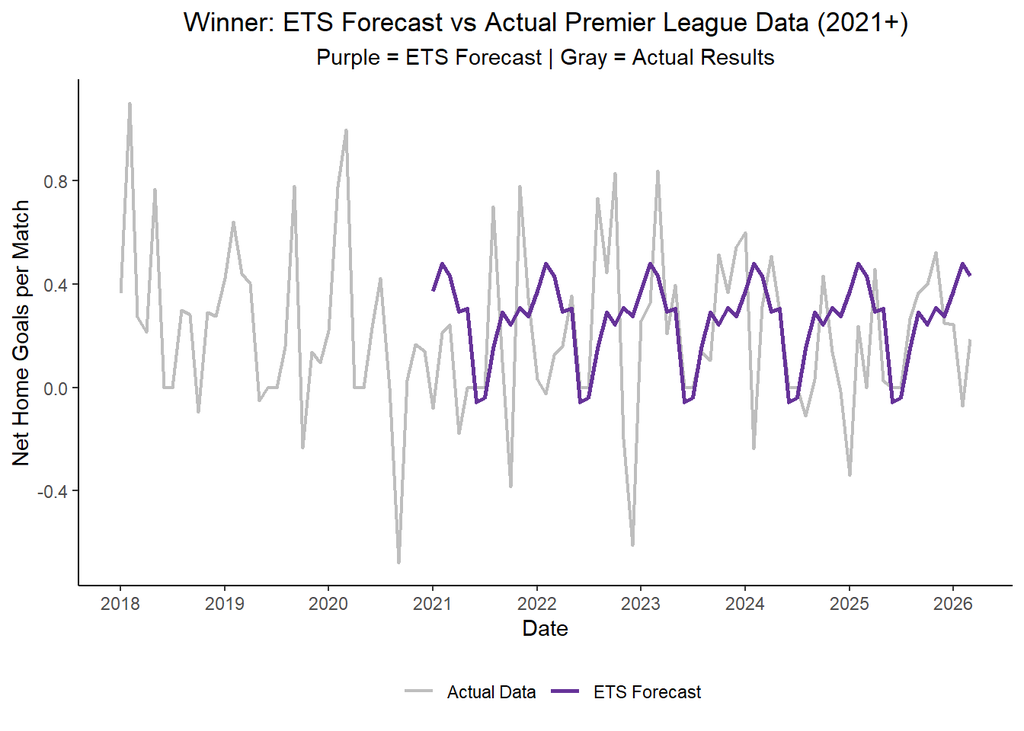

```r
# going to plot winning MODEL ETS
# subset 2018+ to zoom in, otherwise kinda chopped
actual_data_recent <- monthly_prem |> filter(year(Month) >= 2018)

# plot for forecasting
ggplot() +
  # Plot the actual and testing data in gray
  geom_line(data = actual_data_recent, aes(x = Month, y = Avg_Home_Advantage, color = "Actual Data"), linewidth = 0.8) +
  # Plot ONLY the point forecast in purple (fable automatically saves this as .mean)
  geom_line(data = forecast_ets, aes(x = Month, y = .mean, color = "ETS Forecast"), linewidth = 1) +

  # Set colors
  scale_color_manual(values = c("Actual Data" = "gray", "ETS Forecast" = "#663399")) +

  # Clean labels and titles
  labs(title = "Winner: ETS Forecast vs Actual Premier League Data (2021+)",
       subtitle = "Purple = ETS Forecast | Gray = Actual Results",
       x = "Date",
       y = "Net Home Goals per Match",
       color = "") +

  # Clean up the axes and theme
  scale_y_continuous(labels = function(x) sprintf("%.1f", x)) +
  scale_x_yearmonth(date_breaks = "1 year", date_labels = "%Y") +
  theme_classic() +
  theme(plot.title = element_text(hjust = 0.5),
        plot.subtitle = element_text(hjust = 0.5),
        legend.position = "bottom")
```

FINAL COMMENTS:

I think this is such a cool concept and I had a lot of fun doing this project. I never once (maybe in the begging) though of it as homework, and i actually had a lot of fun doing this project. This project made me remember that using sports data and forecast was my initial passion for choosing data analytics as a freshman!!